# Practical Machine Learning - Course Project

Robert Matson

February 20, 2016

## Our mission

##### Quoted directly from the project outline

Using devices such as Jawbone Up, Nike FuelBand, and Fitbit it is now possible to collect a large amount of data about personal activity relatively inexpensively. These type of devices are part of the quantified self movement – a group of enthusiasts who take measurements about themselves regularly to improve their health, to find patterns in their behavior, or because they are tech geeks. One thing that people regularly do is quantify how much of a particular activity they do, but they rarely quantify how well they do it.

In this project, your goal will be to use data from accelerometers on the belt, forearm, arm, and dumbell of 6 participants. They were asked to perform barbell lifts correctly and incorrectly in 5 different ways. More information is available from the website here: http://groupware.les.inf.puc-rio.br/har (see the section on the Weight Lifting Exercise Dataset).

### Data

```r
trainingDataCsv <- "trainingData.csv"
testingDataCsv <- "testing.csv"
```

The training data set for this project is available here:  
https://d396qusza40orc.cloudfront.net/predmachlearn/pml-training.csv

The test data set is available here:  
https://d396qusza40orc.cloudfront.net/predmachlearn/pml-testing.csv

### Required libraries

The following libraries are requiuired and assumed to be installed. Additionally the version of caret is shown.

```r
library("caret")
library("data.table")
library("arm")
packageVersion("caret")
```

```
## [1] '6.0.64'
```

### Download data and initial exploration

First we use the “fread” function from the “data.table” package to read the data, using blank and “NA” as the NA strings. The data structure is both large and sparse. Analysing in detail would make the project excessively large in terms of the number of pages, so for brevity the specifics of this analysis are not included. We will get rid of columns that have a large proportion of “NA” values and where we cannot infer any reasonable value. The first seven columns were date/time or indentification values and in my opinion are not relevant to any predictive model and therefore were removed.

```r
trainingDataSet <- fread(trainingDataCsv, na.strings=c("", "NA"))
testingDataSet <- fread(testingDataCsv, na.strings=c("", "NA"))
nonSparseColumns <- colSums(is.na(trainingDataSet)) <= nrow(trainingDataSet) * 0.9
irrelevantColumns <- c(1,2,3,4,5,6,7)
#Convert to a data frame and then select the columns
trainingDataSet <- data.frame(trainingDataSet)[ , nonSparseColumns]
#Remove the first 7 columns, because this data is irrelevant (Name, Date/Time, row index, ...)
trainingDataSet <- trainingDataSet[ , -irrelevantColumns]
testingDataSet <- data.frame(testingDataSet)[ , nonSparseColumns]
testingDataSet <- testingDataSet[ , -irrelevantColumns]
```

The number of columns removed because of sparse data is 60. Some attributes may have a low variance, which means that the attribute values will be nearly the same for all observations. This data can impact the model and should be removed, if there are any low variance attributes. The caret package provides us with a useful utility to find any such attributes. There appear to be none but it is always worth checking so that we can simplify any model and not include correlated predictors.

```r
lowVariance <- nearZeroVar(trainingDataSet, saveMetrics=T)
lowVariance[lowVariance$nzv == TRUE,]
```

```
## [1] freqRatio     percentUnique zeroVar       nzv
## <0 rows> (or 0-length row.names)
```

```r
trainingDataSet <- trainingDataSet[, !(lowVariance$nzv)]
testingDataSet <- testingDataSet[, !(lowVariance$nzv)]
```

We will also check for any predictors that are highly correlated so we will remove the highly correlated predictors, those with absolute correlations above 0.8 .

```r
# classe is the last attribute, remove it for the correlation function
colCount <- dim(trainingDataSet)[2]
trainingCorr <- cor(trainingDataSet[, -colCount])
highlyCorPred <- findCorrelation(trainingCorr, cutoff=0.8)
trainingDataSet <- trainingDataSet[,-highlyCorPred]
trainingDataSet <- trainingDataSet[,-highlyCorPred]
```

Now that we have our attributes with which we will try to find a model, we will convert the response variable to a factor, i.e. a categorical variable. Right now “classe” is a character string, based on how we loaded the data, which did not convert strings to factors.

```r
trainingDataSet$classe <- as.factor(trainingDataSet$classe)
```

### Partition the Data

Now we will partition our data into a training and validation set. We will take 60% of our data for training the model and the remaining 40% for model validation. We will split over the response variable.

```r
set.seed(8020)
trainIndex <- createDataPartition(trainingDataSet$classe, p=0.6, list=FALSE, times=1)
trainingSet <- trainingDataSet[trainIndex,]
validationSet <- trainingDataSet[-trainIndex,]
```

### Finding our Model

We will use 10 fold cross-validation. The data size is reasonably large so 10 folds still gives a good sized training set for each fold. I considered using repeated cross validation but decided against it for performance reasons. I might later return to this and try repeated CV along with parallel processing.

```r
fitControl <- trainControl(method="cv", number=10)
```

1. Generalised Boosted Model (GBM).

```r
gbm.fit <- train(classe ~ . , data=trainingSet,
                 method="gbm", trControl=fitControl, verbose=FALSE)
gbm.fit
```

```
## Stochastic Gradient Boosting
##
## 11776 samples
##    27 predictors
##     5 classes: 'A', 'B', 'C', 'D', 'E'
##
## No pre-processing
## Resampling: Cross-Validated (10 fold)
## Summary of sample sizes: 10598, 10598, 10597, 10600, 10598, 10598, ...
## Resampling results across tuning parameters:
##
##   interaction.depth  n.trees  Accuracy   Kappa      Accuracy SD
##   1                   50      0.6977750  0.6153837  0.008416483
##   1                  100      0.7505106  0.6829439  0.006306553
##   1                  150      0.7850744  0.7270779  0.006605331
##   2                   50      0.7928030  0.7366846  0.010537515
##   2                  100      0.8440928  0.8022929  0.009647894
##   2                  150      0.8704189  0.8358037  0.012747731
##   3                   50      0.8320319  0.7868972  0.009612898
##   3                  100      0.8811984  0.8494971  0.006180962
##   3                  150      0.9086298  0.8842974  0.008411010
##   Kappa SD
##   0.010524585
##   0.007955962
##   0.008407290
##   0.013412659
##   0.012216695
##   0.016098529
##   0.012144598
##   0.007740817
##   0.010628668
##
## Tuning parameter 'shrinkage' was held constant at a value of 0.1
##
## Tuning parameter 'n.minobsinnode' was held constant at a value of 10
## Accuracy was used to select the optimal model using  the largest value.
## The final values used for the model were n.trees = 150,
##  interaction.depth = 3, shrinkage = 0.1 and n.minobsinnode = 10.
```

2. Random Forest model.

```r
rf.fit1 <- train(classe ~ . , data=trainingSet,
                 method="rf", trControl=fitControl, verbose=FALSE)
rf.fit1
```

```
## Random Forest
##
## 11776 samples
##    27 predictors
##     5 classes: 'A', 'B', 'C', 'D', 'E'
##
## No pre-processing
## Resampling: Cross-Validated (10 fold)
## Summary of sample sizes: 10599, 10598, 10597, 10599, 10598, 10598, ...
## Resampling results across tuning parameters:
##
##   mtry  Accuracy   Kappa      Accuracy SD  Kappa SD
##    2    0.9841207  0.9799062  0.002887537  0.003657100
##   14    0.9806388  0.9755041  0.001588470  0.002013013
##   27    0.9673912  0.9587427  0.004479382  0.005661852
##
## Accuracy was used to select the optimal model using  the largest value.
## The final value used for the model was mtry = 2.
```

Random Forest gives the highest prediction accuracy. Let us see how both models do on the validation data set, which is the data that we took for validating the model created using the training data.

```r
gbmPredict <- predict(gbm.fit, validationSet)
rfPredict1 <- predict(rf.fit1, validationSet)
```

### Prediction performance using the Validation Data Set

```r
gbmPredict.cm <- confusionMatrix(gbmPredict, validationSet$classe)
gbmPredictAccuracy <- round(gbmPredict.cm$overall["Accuracy"],4)
rfPredict1.cm <- confusionMatrix(rfPredict1, validationSet$classe)
rfPredictAccuracy <- round(rfPredict1.cm$overall["Accuracy"], 4)
```

```r
gbmPredict.cm
```

```
## Confusion Matrix and Statistics
##
##           Reference
## Prediction    A    B    C    D    E
##          A 2160  110   21   17   10
##          B   25 1252   65   14   60
##          C   21  114 1261   72   44
##          D   23   24   16 1166   40
##          E    3   18    5   17 1288
##
## Overall Statistics
##
##                Accuracy : 0.9084
##                  95% CI : (0.9018, 0.9147)
##     No Information Rate : 0.2845
##     P-Value [Acc > NIR] : < 2.2e-16
##
##                   Kappa : 0.884
##  Mcnemar's Test P-Value : < 2.2e-16
##
## Statistics by Class:
##
##                      Class: A Class: B Class: C Class: D Class: E
## Sensitivity            0.9677   0.8248   0.9218   0.9067   0.8932
## Specificity            0.9719   0.9741   0.9613   0.9843   0.9933
## Pos Pred Value         0.9318   0.8842   0.8340   0.9188   0.9677
## Neg Pred Value         0.9870   0.9586   0.9831   0.9818   0.9764
## Prevalence             0.2845   0.1935   0.1744   0.1639   0.1838
## Detection Rate         0.2753   0.1596   0.1607   0.1486   0.1642
## Detection Prevalence   0.2954   0.1805   0.1927   0.1617   0.1696
## Balanced Accuracy      0.9698   0.8994   0.9415   0.9455   0.9432
```

```r
rfPredict1.cm
```

```
## Confusion Matrix and Statistics
##
##           Reference
## Prediction    A    B    C    D    E
##          A 2225   29    1    0    1
##          B    6 1466   19    0    3
##          C    0   23 1343   39    5
##          D    1    0    5 1247    4
##          E    0    0    0    0 1429
##
## Overall Statistics
##
##                Accuracy : 0.9827
##                  95% CI : (0.9795, 0.9854)
##     No Information Rate : 0.2845
##     P-Value [Acc > NIR] : < 2.2e-16
##
##                   Kappa : 0.9781
##  Mcnemar's Test P-Value : NA
##
## Statistics by Class:
##
##                      Class: A Class: B Class: C Class: D Class: E
## Sensitivity            0.9969   0.9657   0.9817   0.9697   0.9910
## Specificity            0.9945   0.9956   0.9897   0.9985   1.0000
## Pos Pred Value         0.9863   0.9813   0.9525   0.9920   1.0000
## Neg Pred Value         0.9987   0.9918   0.9961   0.9941   0.9980
## Prevalence             0.2845   0.1935   0.1744   0.1639   0.1838
## Detection Rate         0.2836   0.1868   0.1712   0.1589   0.1821
## Detection Prevalence   0.2875   0.1904   0.1797   0.1602   0.1821
## Balanced Accuracy      0.9957   0.9807   0.9857   0.9841   0.9955
```

With a 95% confidence interval of classifying between 97.95 and 98.54 of the classes correctly, this is a very high rate.

### Can we simplify the model ?

We do have a model that has potentially many predictors and we might be able to simplify this model and keep a similar accuracy. Below we show the variable importance and by removing less important parameters maybe we could find a more parsimonious model.

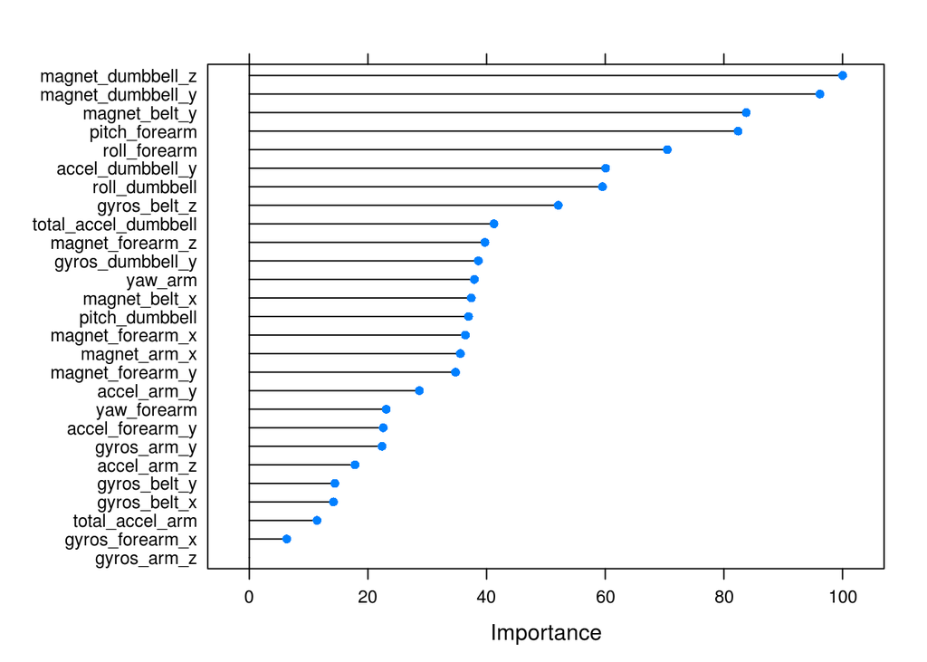

```r
importanceThreshold <- 20
predictorImportance <- varImp(rf.fit1)
plot(predictorImportance)
```

```r
varImportance <- predictorImportance[[1]]
importantVariables <- rownames(varImportance)[order(rowSums(varImportance), decreasing=TRUE)][rowSums(varImportance) > importanceThreshold]
simpleCount <- length(importantVariables)
importantVariables <- c(importantVariables, "classe")
```

Now that we have the most important variables, we will generate a new model model. There are several predictors with a low important so to make the model more understandable we can remove the low importance variables and check the accuracy. I have selected the 21 most important parameters, based on having a scaled importance of more than 20 and we will run the Random Forest model generation using these variables.

```r
trainingSet2 <- trainingSet[, importantVariables]
rf.fit2 <- train(classe ~ ., data=trainingSet2,
                 method="rf", trControl=fitControl, verbose=FALSE)
rf.fit2
```

```
## Random Forest
##
## 11776 samples
##    21 predictors
##     5 classes: 'A', 'B', 'C', 'D', 'E'
##
## No pre-processing
## Resampling: Cross-Validated (10 fold)
## Summary of sample sizes: 10598, 10599, 10597, 10598, 10598, 10600, ...
## Resampling results across tuning parameters:
##
##   mtry  Accuracy   Kappa      Accuracy SD  Kappa SD
##    2    0.9767337  0.9705635  0.006909639  0.008745633
##   11    0.9712992  0.9636971  0.007418300  0.009383108
##   21    0.9600049  0.9494104  0.008698641  0.010991585
##
## Accuracy was used to select the optimal model using  the largest value.
## The final value used for the model was mtry = 2.
```

Let us see how well it predicts using the validation set.

```r
predict.rf.2 <- predict(rf.fit2, validationSet)
predict.rf.2.cm <- confusionMatrix(predict.rf.2, validationSet$classe)
predict.rf.2.cm
```

```
## Confusion Matrix and Statistics
##
##           Reference
## Prediction    A    B    C    D    E
##          A 2218   30    5    2    1
##          B    6 1457   17    0    2
##          C    2   31 1335   45    4
##          D    6    0   11 1239    5
##          E    0    0    0    0 1430
##
## Overall Statistics
##
##                Accuracy : 0.9787
##                  95% CI : (0.9753, 0.9818)
##     No Information Rate : 0.2845
##     P-Value [Acc > NIR] : < 2.2e-16
##
##                   Kappa : 0.9731
##  Mcnemar's Test P-Value : NA
##
## Statistics by Class:
##
##                      Class: A Class: B Class: C Class: D Class: E
## Sensitivity            0.9937   0.9598   0.9759   0.9635   0.9917
## Specificity            0.9932   0.9960   0.9873   0.9966   1.0000
## Pos Pred Value         0.9832   0.9831   0.9421   0.9826   1.0000
## Neg Pred Value         0.9975   0.9904   0.9949   0.9929   0.9981
## Prevalence             0.2845   0.1935   0.1744   0.1639   0.1838
## Detection Rate         0.2827   0.1857   0.1702   0.1579   0.1823
## Detection Prevalence   0.2875   0.1889   0.1806   0.1607   0.1823
## Balanced Accuracy      0.9935   0.9779   0.9816   0.9800   0.9958
```

This gives us an accuracy value of 0.9787, and a 95% CI of ana ccuracy level of between 0.9753 and 0.9818. This slightly simpler model gives us a similar but a slighty lower accuracy rate when compared to the optimum model found earlier.

### Using the test data to make predictions

Now using the test set, and our optimum Random Forest prediction model, we get the predictions below for the first 20 elements of the test data, using the Random Forest model with the highest accuracy.

```r
predict.rf.1.test <- predict(rf.fit1, testingDataSet)
predict.rf.1.test[1:20]
```

```
##  [1] B A B A A E D B A A B C B A E E A B B B
## Levels: A B C D E
```

### Out of Sample Error

```r
ose <- sum(predict.rf.1.test == validationSet$classe)/length(predict.rf.1.test)
ose
```

[output not shown]